# Final Project

Lastly, I wanted to know what the data could tell me about use of seat belts based on age range. I loaded the same restraint data as before and did some of the same cleaning to get the levels in the right order then plotted the fatalities by age group.

```r
restraint.age = read.table('restraint.xls', sep = '\t', header = TRUE, skip=2)
restraint.age = restraint.age[-10]

#Drop total category
restraint.age$FieldDesc = droplevels(restraint.age$FieldDesc, exclude = "Total")
restraint.age = na.omit(restraint.age)
#Levels out of order
levels(restraint.age$FieldDesc)
```

```
##  [1] "< 5"      "> 74"     "10 -- 15" "16 -- 20" "21 -- 24" "25 -- 34"
##  [7] "35 -- 44" "45 -- 54" "5 -- 9"   "55 -- 64" "65 -- 74" "Unknown"
```

```r
restraint.age$FieldDesc = ordered(restraint.age$FieldDesc, levels=c('< 5','5 -- 9','10 -- 15','16 -- 20', '21 -- 24', '25 -- 34', '35 -- 44', '45 -- 54', '55 -- 64', '65 -- 74', '75 +', '> 74', 'Unknown'))
head(restraint.age)
```

```
##   FieldDesc Restraint.Used Percent Restraint.Not.Used Percent1
## 1       < 5            215    71.4                 66     21.9
## 2    5 -- 9            131    56.0                 78     33.3
## 3  10 -- 15            154    39.1                191     48.5
## 4  16 -- 20           1034    43.7               1102     46.6
## 5  21 -- 24            917    38.4               1231     51.6
## 6  25 -- 34           1588    36.4               2292     52.6
##   Restraint.Use.Unknown Percent2 Total Percent3
## 1                    20      6.6   301      100
## 2                    25     10.7   234      100
## 3                    49     12.4   394      100
## 4                   230      9.7  2366      100
## 5                   238     10.0  2386      100
## 6                   478     11.0  4358      100
```

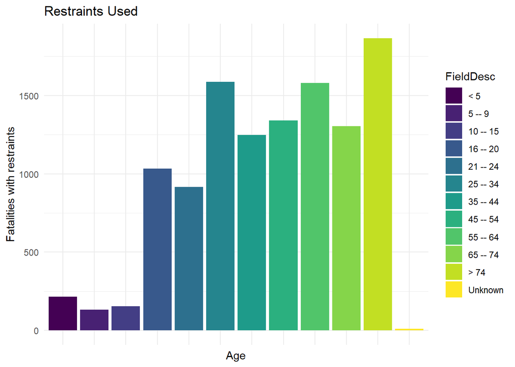

```r
#Plot restraints used by age
ggplot(restraint.age, aes(FieldDesc,Restraint.Used,fill=FieldDesc)) +
  geom_bar(stat="Identity") +
  labs(title="Restraints Used", y="Fatalities with restraints",x="Age") +
  theme_minimal() +
  theme(axis.text.x=element_blank())
```

The age group with the most fatalities for those who used restraints was over 74 years old. To me this makes sense because older people probably tend to wear seatbelts more often than younger age groups.

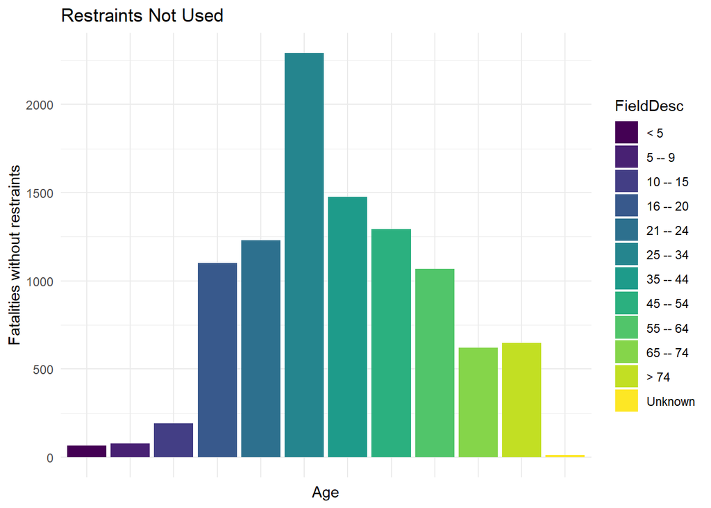

```r
#Plot resytaints not used by age
ggplot(restraint.age, aes(FieldDesc,Restraint.Not.Used,fill=FieldDesc)) +
  geom_bar(stat="Identity") +
  labs(title="Restraints Not Used", y="Fatalities without restraints",x="Age") +
  theme_minimal() +
  theme(axis.text.x=element_blank())
```

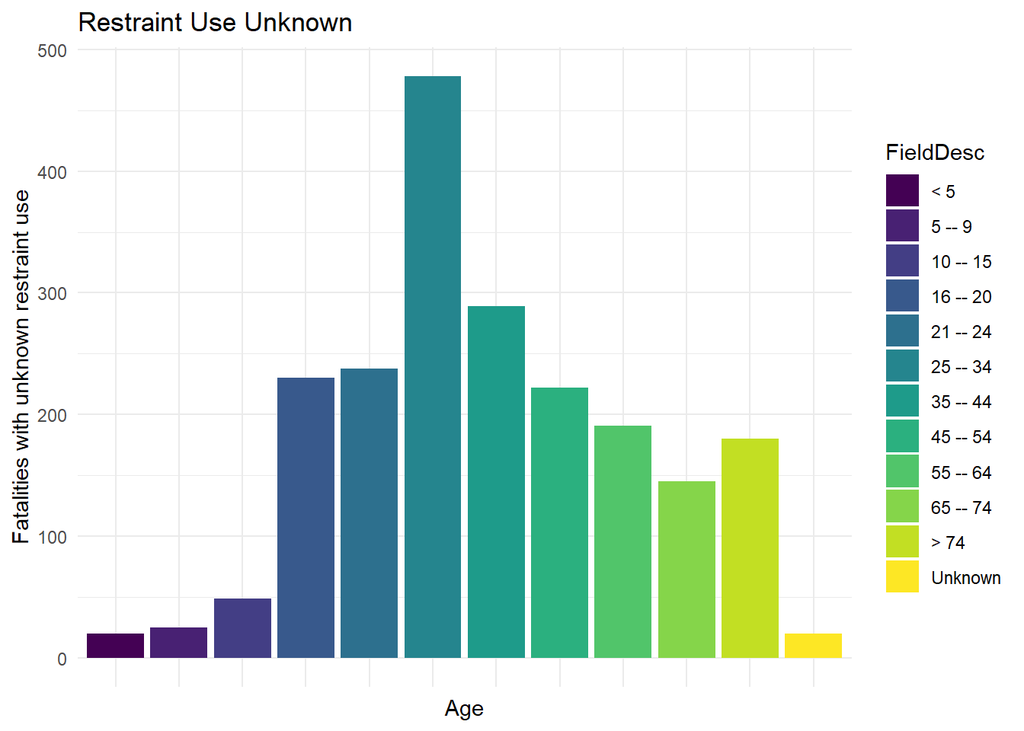

```r
ggplot(restraint.age, aes(FieldDesc,Restraint.Use.Unknown,fill=FieldDesc)) +
  geom_bar(stat="Identity") +
  labs(title="Restraint Use Unknown",y="Fatalities with unknown restraint use",x="Age") +
  theme_minimal() +
  theme(axis.text.x=element_blank())
```

**Challenges**  
Although the data was very clean with very few missing values, the way some of the tables were layed out was difficult for me to work with. It was challenging to get the data into the form I needed for certain visualizations. I struggled with joining the data for age ranges since there were so many tables to work with. I ended up using merge functions to join the data because it was the most straight forward way I could find. It also took me a long time to rearrange the data for seatbelt use and plot the total percentages. Initially, I wanted to make a proportion plot as I did before in labs and homework. For some reason none of the percentages would plot correctly and I resorted to a regular bar plot instead. I had also originally planned to do further visualization using the gender data, but realized later that the tables for all years (1994-2017) were all exactly the same. Because of that, I wasn’t able to plot the gender ratios for each year as I had originally planned.

**Citations**  
merging data frames: https://jozef.io/r006-merge/